# IST 707 Group Project

Daquan Morrison,Zachary Blaine-Atkins, Quintin Covington

2024-06-13

# Introduction

Dogs, often celebrated as humanity’s best friend, have played a multifaceted role in human society for thousands of years. Their domestication dates back over 15,000 years, making them one of the first animals to form a bond with humans. Initially, dogs were indispensable partners in hunting and herding. Their keen senses and loyalty made them ideal companions for early human societies, aiding in food acquisition and the protection of livestock.

Throughout history, the utility of dogs has evolved. In ancient civilizations such as Egypt, Greece, and Rome, dogs were not only working animals but also symbols of status and companionship. In medieval Europe, they were employed in various roles including guard dogs, hunting aids, and even war companions. The Industrial Revolution and subsequent urbanization saw a shift in the role of dogs from primarily working animals to cherished household pets.

In contemporary times, dogs serve a variety of purposes beyond companionship. They are integral to law enforcement as K9 units, assist in search and rescue missions, and provide therapeutic benefits as service and emotional support animals. The deep bond between dogs and humans has led to the emergence of pet adoption as a significant societal practice. Organizations and shelters worldwide advocate for the adoption of dogs, emphasizing the benefits of giving a home to an animal in need.

Despite the love and care many dogs receive, there is a significant issue of abandonment. Millions of dogs are abandoned each year due to various reasons, including behavioral problems, economic hardship, and changes in the owner’s living situation. This abandonment leads to overcrowded shelters and, in some unfortunate cases, euthanasia. Pet adoption not only helps in providing homes to these abandoned animals but also alleviates the pressure on animal shelters, contributing to a more humane society.

The aim of this project is to classify dog breeds into optimal categories for potential owners based on characteristics such as temperament, size, energy level, and maintenance needs. By matching breeds with specific lifestyles—Busy Families, Single Professionals, Home-Oriented Individuals, Active Singles, and Work-from-Home Individuals—we intend to improve owner-dog compatibility. This approach will help prospective dog owners, adoption agencies, and breeders make better-informed decisions.

# About the Data

For data cleaning and preparation, missing values were either filled based on similar entries or removed if insignificant. Incorrect values were corrected using reliable breed characteristics. Outliers were identified through statistical methods and visualizations, corrected if erroneous, or retained if legitimate. New features were generated to enhance analysis, such as a composite score for adaptability. Since the dataset primarily contains categorical variables, normalization was generally not required, though numerical representations were normalized for certain analyses.

# Exploratory Data Analysis

Load Libraries and Data

```r
# Load necessary libraries
library(dplyr)
```

```r
library(tidyr)
library(stringr)
library(purrr)
library(rpart)
library(rpart.plot)
library(caret)
library(arules)
library(stats)
library(readxl)
library(caret)
library(randomForest)
library(e1071)
library(class)
library(kknn)
library(nnet)
library(ggplot2)
library(corrplot)
# Load the data
dog_adaptability_test_data <- read.csv("C:/Users/Daquan Morrison/Downloads/dog adaptability test_data.csv")
sum(is.na(dog_adaptability_test_data))
```

```
## [1] 0
```

```r
#Overview of the Dataset and Columns
glimpse(dog_adaptability_test_data)
```

```
## Rows: 800
## Columns: 34
## $ id                         <int> 3200, 3201, 3202, 3203, 3204, 3205, 3206, 3…
## $ adaptability               <int> 3, 3, 3, 4, 3, 3, 3, 3, 4, 4, 4, 4, 3, 3, 4…
## $ good_for_novice_owners     <int> 2, 3, 2, 1, 2, 2, 2, 2, 3, 2, 5, 4, 1, 2, 3…
## $ sensitivity_level          <int> 4, 4, 4, 5, 4, 4, 4, 4, 3, 5, 5, 3, 4, 4, 3…
## $ tolerates_being_alone      <int> 2, 4, 1, 2, 3, 3, 1, 1, 4, 1, 1, 3, 3, 2, 2…
## $ tolerates_cold_weather     <int> 5, 3, 3, 2, 5, 4, 3, 2, 1, 2, 2, 1, 3, 5, 4…
## $ tolerates_hot_weather      <int> 4, 3, 3, 4, 4, 3, 4, 2, 3, 4, 4, 4, 1, 3, 2…
## $ all_around_friendliness    <int> 4, 3, 4, 5, 5, 4, 4, 4, 4, 4, 4, 3, 4, 5, 4…
## $ affectionate_with_family   <int> 5, 4, 5, 5, 5, 5, 5, 5, 4, 4, 5, 4, 5, 5, 5…
## $ incredibly_kifriendly_dogs <int> 2, 1, 5, 5, 5, 4, 4, 4, 4, 3, 3, 3, 5, 3, 5…
## $ dog_friendly               <int> 2, 4, 2, 5, 3, 4, 3, 3, 2, 3, 2, 1, 4, 3, 3…
## $ friendly_towarstrangers    <int> 3, 2, 4, 5, 4, 3, 2, 2, 2, 5, 1, 3, 3, 4, 5…
## $ health_grooming            <int> 3, 3, 4, 3, 4, 4, 3, 4, 3, 3, 2, 3, 2, 3, 3…
```

[output cut: 21 more lines]

```r
#Summary of the data
summary(dog_adaptability_test_data)
```

```
##        id        adaptability   good_for_novice_owners sensitivity_level
##  Min.   :3200   Min.   :2.000   Min.   :1.000          Min.   :2.000
##  1st Qu.:3400   1st Qu.:3.000   1st Qu.:2.000          1st Qu.:3.000
##  Median :3600   Median :3.000   Median :3.000          Median :4.000
##  Mean   :3600   Mean   :3.104   Mean   :2.879          Mean   :3.716
##  3rd Qu.:3799   3rd Qu.:3.000   3rd Qu.:4.000          3rd Qu.:4.000
##  Max.   :3999   Max.   :4.000   Max.   :5.000          Max.   :5.000
##  tolerates_being_alone tolerates_cold_weather tolerates_hot_weather
##  Min.   :1.000         Min.   :1.000          Min.   :1.000
##  1st Qu.:1.000         1st Qu.:2.000          1st Qu.:2.000
##  Median :2.000         Median :3.000          Median :3.000
##  Mean   :2.027         Mean   :3.277          Mean   :2.936
##  3rd Qu.:3.000         3rd Qu.:4.000          3rd Qu.:4.000
##  Max.   :5.000         Max.   :5.000          Max.   :5.000
##  all_around_friendliness affectionate_with_family incredibly_kifriendly_dogs
##  Min.   :1.000           Min.   :2.000            Min.   :1.000
##  1st Qu.:4.000           1st Qu.:4.000            1st Qu.:3.000
##  Median :4.000           Median :5.000            Median :4.000
##  Mean   :3.985           Mean   :4.631            Mean   :4.027
##  3rd Qu.:4.000           3rd Qu.:5.000            3rd Qu.:5.000
##  Max.   :5.000           Max.   :5.000            Max.   :5.000
##   dog_friendly   friendly_towarstrangers health_grooming amount_of_shedding
##  Min.   :1.000   Min.   :1.000           Min.   :2.000   Min.   :1.00
##  1st Qu.:3.000   1st Qu.:2.000           1st Qu.:3.000   1st Qu.:2.00
##  Median :3.000   Median :3.000           Median :3.000   Median :3.00
##  Mean   :3.373   Mean   :3.291           Mean   :3.035   Mean   :2.99
##  3rd Qu.:4.000   3rd Qu.:4.000           3rd Qu.:3.000   3rd Qu.:4.00
##  Max.   :5.000   Max.   :5.000           Max.   :4.000   Max.   :5.00
##  drooling_potential easy_to_groom   general_health  potential_for_weight_gain
##  Min.   :1.000      Min.   :1.000   Min.   :1.000   Min.   :1.000
##  1st Qu.:1.000      1st Qu.:2.000   1st Qu.:3.000   1st Qu.:3.000
##  Median :1.000      Median :4.000   Median :3.000   Median :3.000
##  Mean   :1.762      Mean   :3.518   Mean   :3.389   Mean   :3.221
##  3rd Qu.:2.000      3rd Qu.:5.000   3rd Qu.:4.000   3rd Qu.:4.000
##  Max.   :5.000      Max.   :5.000   Max.   :5.000   Max.   :5.000
##       size        trainability   easy_to_train    intelligence
##  Min.   :1.000   Min.   :2.000   Min.   :1.000   Min.   :1.00
##  1st Qu.:2.000   1st Qu.:3.000   1st Qu.:3.000   1st Qu.:4.00
##  Median :3.000   Median :3.000   Median :3.000   Median :4.00
##  Mean   :2.895   Mean   :3.425   Mean   :3.462   Mean   :4.03
```

[output cut: 15 more lines]

```
##  Max.   :5.000        Max.   :5.000   Max.   :5.000   Max.   :5.000
##  potential_for_playfulness breed_group           height
##  Min.   :1.000             Length:800         Length:800
##  1st Qu.:4.000             Class :character   Class :character
##  Median :4.000             Mode  :character   Mode  :character
##  Mean   :4.312
##  3rd Qu.:5.000
##  Max.   :5.000
##     weight            lifspan
##  Length:800         Length:800
##  Class :character   Class :character
##  Mode  :character   Mode  :character
##
##
##
```

Data Preprocessing Steps

```r
# Convert categorical data to factors
dog_adaptability_test_data$breed_group <- as.factor(dog_adaptability_test_data$breed_group)

# Normalize numeric data
normalize <- function(x) {
  return((x - min(x)) / (max(x) - min(x)))
}
numeric_cols <- sapply(dog_adaptability_test_data, is.numeric)
dog_adaptability_test_data[numeric_cols] <- lapply(dog_adaptability_test_data[numeric_cols], normalize)

library(dplyr)
library(stringr)
```

```r
# Data preprocessing steps
dog_adaptability_test_data <- dog_adaptability_test_data %>%
  select(-tolerates_cold_weather, -tolerates_hot_weather, -drooling_potential,
         -health_grooming, -potential_for_weight_gain, -prey_drive,
         -potential_for_mouthiness, -wanderlust_potential)

dog_adaptability_test_data$breed_group <- as.factor(dog_adaptability_test_data$breed_group)

dog_adaptability_test_data$adaptability <- (dog_adaptability_test_data$adaptability - min(dog_adaptability_test_data$adaptability)) / (max(dog_adaptability_test_data$adaptability) - min(dog_adaptability_test_data$adaptability))
```

Define Functions

```r
# Function to extract numeric ranges from a string
extract_range <- function(text) {
  matches <- str_extract_all(text, "\\d+")[[1]]
  if (length(matches) == 0) {
    return(c(NA, NA))
  }
  nums <- as.numeric(matches)
  if (str_detect(text, "Up to")) {
    return(c(0, nums[1]))
  }
  if (length(nums) == 1) {
    return(c(nums[1], nums[1]))
  }
  return(c(min(nums), max(nums)))
}

# Function to find the average of numeric ranges
find_avg <- function(min_val, max_val) {
  if (is.na(min_val) || is.na(max_val)) {
    return(NA)
  } else {
    return((min_val + max_val) / 2)
  }
}
```

Process Weight Column

```r
# Find average weight
dog_data <- dog_adaptability_test_data %>%
  mutate(weight = as.character(weight),
         weight_range = str_extract(weight, "\\d+ to \\d+")) %>%
  separate(weight_range, into = c("min_weight", "max_weight"), sep = " to ", convert = TRUE, fill = "right") %>%
  mutate(avg_weight = map2_dbl(min_weight, max_weight, find_avg))

# Verify weight processing
head(dog_data[, c("min_weight", "max_weight", "avg_weight")])
```

```
##   min_weight max_weight avg_weight
## 1          3          6        4.5
## 2         13         18       15.5
## 3          9         15       12.0
## 4         25         40       32.5
## 5          7         12        9.5
## 6          9         13       11.0
```

Process Lifespan Column

```r
# Correct column name if necessary
names(dog_data)[names(dog_data) == "lifspan"] <- "lifespan"

# Find average lifespan
dog_data <- dog_data %>%
  mutate(lifespan = as.character(lifespan),
         lifespan_range = str_extract(lifespan, "\\d+ to \\d+")) %>%
  separate(lifespan_range, into = c("min_lifespan", "max_lifespan"), sep = " to ", convert = TRUE, fill = "right") %>%
  mutate(avg_lifespan = map2_dbl(min_lifespan, max_lifespan, find_avg))

# Verify lifespan processing
head(dog_data[, c("min_lifespan", "max_lifespan", "avg_lifespan")])
```

```
##   min_lifespan max_lifespan avg_lifespan
## 1           10           14         12.0
## 2           10           13         11.5
## 3           11           16         13.5
## 4            9           14         11.5
## 5           10           12         11.0
## 6           10           18         14.0
```

Remove Intermediate Columns

```r
# Check if columns exist before removing them
columns_to_remove <- c("min_weight", "max_weight", "min_lifespan", "max_lifespan")
existing_columns <- columns_to_remove[columns_to_remove %in% names(dog_data)]

# Remove intermediate columns if they exist
if(length(existing_columns) > 0) {
  dog_data <- dog_data %>% select(-all_of(existing_columns))
}
```

Create Lifestyle Category Column with Combined Categories

```r
dog_data <- dog_data %>%
  mutate(lifestyle_category = case_when(
    all_around_friendliness >= 3 & potential_for_playfulness >= 3 & affectionate_with_family >= 3 & sensitivity_level >= 3 & trainability >= 3 & easy_to_train >= 3 & energy_level <= 5 & tendency_to_bark_or_howl <= 3 ~ 'Busy Families',
    exercise_needs <= 4 & tolerates_being_alone >= 3 & easy_to_train >= 3 & good_for_novice_owners >= 3 & intelligence >= 3 ~ 'Single Professionals',
    affectionate_with_family >= 3 & incredibly_kifriendly_dogs >= 3 & all_around_friendliness >= 3 & easy_to_train >= 3 ~ 'Home-Based Families',
    (energy_level <= 4 & exercise_needs <= 4 & intensity <= 4 & potential_for_playfulness <= 4 & tendency_to_bark_or_howl <= 4 & tolerates_being_alone <= 3 & intelligence >= 3 & easy_to_groom >= 3 & friendly_towarstrangers >= 3 & good_for_novice_owners >= 3) |
    (affectionate_with_family >= 3 & incredibly_kifriendly_dogs >= 3 & all_around_friendliness >= 3 & easy_to_train >= 3) ~ 'Home-Based Families',
    (energy_level >= 3 & exercise_needs >= 3 & intensity >= 3 & potential_for_playfulness >= 3 & trainability >= 3 & dog_friendly >= 3) ~ 'Active Singles',
    (tolerates_being_alone >= 3 & trainability >= 3 & easy_to_train >= 3 & tendency_to_bark_or_howl <= 3 & exercise_needs <= 4 & potential_for_playfulness <= 4) |
    (exercise_needs <= 4 & tolerates_being_alone >= 3 & easy_to_train >= 3 & good_for_novice_owners >= 3 & intelligence >= 3) ~ 'Single Professionals',
    TRUE ~ 'General'
  ))

# Check class distribution
class_distribution <- table(dog_data$lifestyle_category)
print(class_distribution)
```

```
##
## General
##     800
```

Calculate Weights

```r
# Calculate class weights
total_records <- nrow(dog_data)
class_weights <- total_records / (length(class_distribution) * class_distribution)

# Create a weight vector for each record
dog_data$weights <- sapply(dog_data$lifestyle_category, function(x) class_weights[x])
```

Exploratory Data Analysis

**Visualize the distribution of breeds across lifestyle categories**

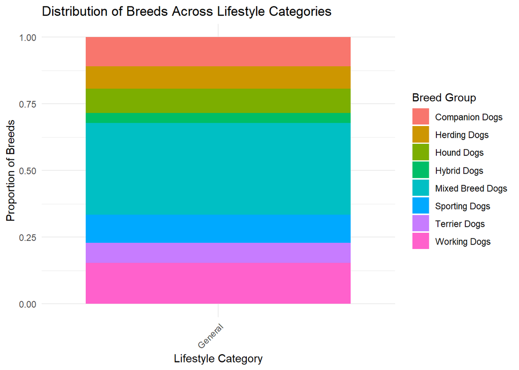

[output not shown]

```r
library(ggplot2)

# Assuming dog_data contains the lifestyle_category column
# Create a bar plot
ggplot(dog_data, aes(x = lifestyle_category, fill = breed_group)) +
  geom_bar(position = "fill") +
  labs(title = "Distribution of Breeds Across Lifestyle Categories",
       x = "Lifestyle Category",
       y = "Proportion of Breeds",
       fill = "Breed Group") +
  theme_minimal() +
  theme(axis.text.x = element_text(angle = 45, hjust = 1))
```

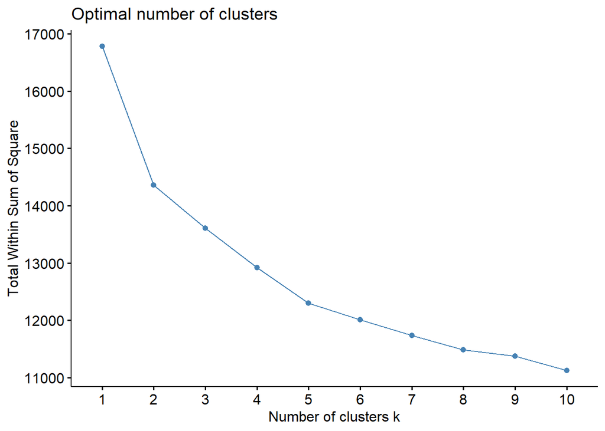

```r
library(arules)

# Select relevant columns for clustering
clustering_data <- dog_data %>%
  select(adaptability, good_for_novice_owners, sensitivity_level, tolerates_being_alone, all_around_friendliness, affectionate_with_family, incredibly_kifriendly_dogs,
         dog_friendly, friendly_towarstrangers, amount_of_shedding,
         easy_to_groom, general_health, size, trainability, easy_to_train, intelligence,
          tendency_to_bark_or_howl, exercise_needs,
         energy_level, intensity, potential_for_playfulness)

# Standardize the data
clustering_data_scaled <- scale(clustering_data)

# Determine the optimal number of clusters using the Elbow method
fviz_nbclust(clustering_data_scaled, kmeans, method = "wss")
```

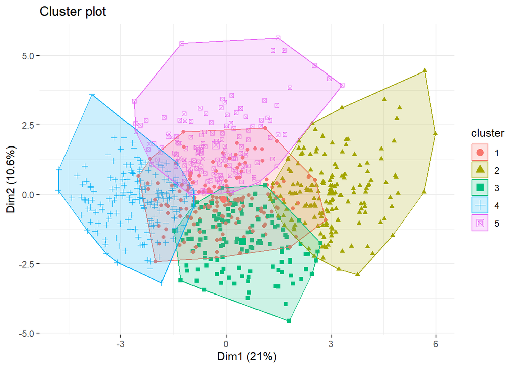

```r
# Perform K-means clustering with 5 clusters
set.seed(123) # Set seed for reproducibility
kmeans_result <- kmeans(clustering_data_scaled, centers = 5, nstart = 25)

# Add the cluster assignments to the original dataset
dog_data$cluster <- kmeans_result$cluster

# Visualize the clusters
fviz_cluster(kmeans_result, data = clustering_data_scaled, geom = "point", ellipse.type = "convex", ggtheme = theme_minimal())
```

```r
# Calculate the mean values of the relevant criteria for each cluster
cluster_means <- dog_data %>%
  group_by(cluster) %>%
  summarise(across(adaptability:potential_for_playfulness, ~ mean(.x, na.rm = TRUE)))

# Print the mean values for each cluster
print(cluster_means)
```

```
## # A tibble: 5 × 22
##   cluster adaptability good_for_novice_owners sensitivity_level
##     <int>        <dbl>                  <dbl>             <dbl>
## 1       1        0.814                  0.752             0.656
## 2       2        0.561                  0.534             0.372
## 3       3        0.523                  0.448             0.641
## 4       4        0.508                  0.338             0.687
## 5       5        0.349                  0.296             0.491
## # ℹ 18 more variables: tolerates_being_alone <dbl>,
## #   all_around_friendliness <dbl>, affectionate_with_family <dbl>,
## #   incredibly_kifriendly_dogs <dbl>, dog_friendly <dbl>,
## #   friendly_towarstrangers <dbl>, amount_of_shedding <dbl>,
## #   easy_to_groom <dbl>, general_health <dbl>, size <dbl>, trainability <dbl>,
## #   easy_to_train <dbl>, intelligence <dbl>, tendency_to_bark_or_howl <dbl>,
## #   exercise_needs <dbl>, energy_level <dbl>, intensity <dbl>, …
```

```r
# Assign lifestyle categories based on clusters
dog_data <- dog_data %>%
  mutate(lifestyle_category = case_when(
    cluster == 1 ~ "Busy Families",
    cluster == 2 ~ "Single Professionals",
    cluster == 3 ~ "Home-Based Families",
    cluster == 4 ~ "Active Singles",
    cluster == 5 ~ "Retired Couples or Singles",
    TRUE ~ "Other"
  ))

# Print the updated dataset with lifestyle categories
print(head(dog_data))
```

```
##            id adaptability good_for_novice_owners sensitivity_level
## 1 0.000000000          0.5                   0.25         0.6666667
## 2 0.001251564          0.5                   0.50         0.6666667
## 3 0.002503129          0.5                   0.25         0.6666667
## 4 0.003754693          1.0                   0.00         1.0000000
## 5 0.005006258          0.5                   0.25         0.6666667
## 6 0.006257822          0.5                   0.25         0.6666667
##   tolerates_being_alone all_around_friendliness affectionate_with_family
## 1                  0.25                    0.75                1.0000000
## 2                  0.75                    0.50                0.6666667
## 3                  0.00                    0.75                1.0000000
## 4                  0.25                    1.00                1.0000000
## 5                  0.50                    1.00                1.0000000
## 6                  0.50                    0.75                1.0000000
##   incredibly_kifriendly_dogs dog_friendly friendly_towarstrangers
```

[output cut: 48 more lines]

```r
# Load necessary library
library(dplyr)

# Define the function to calculate the average of numeric columns for a specific breed group
calculate_average_by_breed_group <- function(data, breed_group) {
  average_values <- data %>%
    filter(breed_group == !!breed_group) %>%
    select_if(is.numeric) %>%
    summarise(across(everything(), mean, na.rm = TRUE))

  return(average_values)
}

# Use of the function for different breed groups
companion_average_values <- calculate_average_by_breed_group(dog_adaptability_test_data, "Companion Dogs")
working_average_values <- calculate_average_by_breed_group(dog_adaptability_test_data, "Working Dogs")
terrier_average_values <- calculate_average_by_breed_group(dog_adaptability_test_data, "Terrier Dogs")
hybrid_average_values <- calculate_average_by_breed_group(dog_adaptability_test_data, "Hybrid Dogs")
hound_average_values <- calculate_average_by_breed_group(dog_adaptability_test_data, "Hound Dogs")
mixed_average_values <- calculate_average_by_breed_group(dog_adaptability_test_data, "Mixed Breed Dogs")
herding_average_values <- calculate_average_by_breed_group(dog_adaptability_test_data, "Herding Dogs")
sporting_average_values <- calculate_average_by_breed_group(dog_adaptability_test_data, "Sporting Dogs")

# Print the result
print(companion_average_values)
```

```
##         id adaptability good_for_novice_owners sensitivity_level
## 1 0.454389    0.6818182              0.6931818         0.5984848
##   tolerates_being_alone all_around_friendliness affectionate_with_family
## 1             0.2528409               0.7272727                0.8560606
##   incredibly_kifriendly_dogs dog_friendly friendly_towarstrangers
## 1                  0.6960227    0.5681818               0.5596591
##   amount_of_shedding easy_to_groom general_health      size trainability
## 1          0.3579545     0.4971591      0.6079545 0.2982955    0.4166667
##   easy_to_train intelligence tendency_to_bark_or_howl exercise_needs
## 1     0.6221591    0.7073864                      0.5      0.5454545
##   energy_level intensity potential_for_playfulness
## 1    0.5265152 0.4772727                 0.7897727
```

```r
print(working_average_values)
```

```
##        id adaptability good_for_novice_owners sensitivity_level
## 1 0.52815    0.3617886              0.2723577         0.4579946
##   tolerates_being_alone all_around_friendliness affectionate_with_family
## 1             0.3292683               0.7784553                0.9159892
##   incredibly_kifriendly_dogs dog_friendly friendly_towarstrangers
## 1                  0.7926829    0.5914634               0.5447154
##   amount_of_shedding easy_to_groom general_health      size trainability
## 1           0.699187      0.550813      0.4837398 0.6890244    0.4498645
##   easy_to_train intelligence tendency_to_bark_or_howl exercise_needs
## 1     0.6117886    0.7418699                0.4471545      0.6124661
##   energy_level intensity potential_for_playfulness
## 1    0.5745257 0.5264228                 0.7723577
```

```r
print(terrier_average_values)
```

```
##          id adaptability good_for_novice_owners sensitivity_level
## 1 0.4885899         0.65              0.5416667         0.5555556
##   tolerates_being_alone all_around_friendliness affectionate_with_family
## 1                0.2625               0.7291667                0.8277778
##   incredibly_kifriendly_dogs dog_friendly friendly_towarstrangers
## 1                  0.7333333        0.625                   0.575
##   amount_of_shedding easy_to_groom general_health      size trainability
## 1          0.4083333     0.5791667      0.6791667 0.3791667    0.5444444
##   easy_to_train intelligence tendency_to_bark_or_howl exercise_needs
## 1     0.6083333    0.7583333                0.6166667      0.7222222
##   energy_level intensity potential_for_playfulness
## 1    0.7388889 0.6208333                 0.8291667
```

```r
print(hybrid_average_values)
```

```
##          id adaptability good_for_novice_owners sensitivity_level
## 1 0.4833542          0.7              0.6166667         0.5666667
##   tolerates_being_alone all_around_friendliness affectionate_with_family
## 1             0.3333333               0.7916667                0.9222222
##   incredibly_kifriendly_dogs dog_friendly friendly_towarstrangers
## 1                  0.7083333        0.625               0.5666667
##   amount_of_shedding easy_to_groom general_health      size trainability
## 1          0.4416667           0.5      0.5333333 0.4416667    0.4444444
##   easy_to_train intelligence tendency_to_bark_or_howl exercise_needs
## 1     0.6083333        0.775                      0.4      0.6333333
##   energy_level intensity potential_for_playfulness
## 1    0.6555556 0.5333333                 0.8416667
```

```r
print(hound_average_values)
```

```
##          id adaptability good_for_novice_owners sensitivity_level
## 1 0.5130728    0.5410959              0.4006849         0.6210046
##   tolerates_being_alone all_around_friendliness affectionate_with_family
## 1             0.3013699               0.7773973                0.8538813
##   incredibly_kifriendly_dogs dog_friendly friendly_towarstrangers
## 1                  0.8390411    0.6609589                0.640411
##   amount_of_shedding easy_to_groom general_health      size trainability
## 1          0.4965753     0.6849315      0.6780822 0.4794521    0.5570776
##   easy_to_train intelligence tendency_to_bark_or_howl exercise_needs
## 1      0.510274    0.7705479                0.5993151      0.7351598
##   energy_level intensity potential_for_playfulness
## 1    0.7671233 0.6232877                 0.8458904
```

```r
print(mixed_average_values)
```

```
##          id adaptability good_for_novice_owners sensitivity_level
## 1 0.5026301     0.548913              0.4918478          0.615942
##   tolerates_being_alone all_around_friendliness affectionate_with_family
## 1              0.201087               0.7192029                0.8695652
##   incredibly_kifriendly_dogs dog_friendly friendly_towarstrangers
## 1                  0.7300725    0.5597826               0.5525362
##   amount_of_shedding easy_to_groom general_health      size trainability
## 1          0.4673913     0.7346014      0.6014493 0.4501812    0.4541063
##   easy_to_train intelligence tendency_to_bark_or_howl exercise_needs
## 1     0.6322464    0.7554348                0.5117754      0.6944444
##   energy_level intensity potential_for_playfulness
## 1    0.6968599 0.5914855                 0.8405797
```

```r
print(herding_average_values)
```

```
##          id adaptability good_for_novice_owners sensitivity_level
## 1 0.5026548    0.5833333              0.4810606         0.5656566
##   tolerates_being_alone all_around_friendliness affectionate_with_family
## 1             0.2651515               0.7159091                0.8888889
##   incredibly_kifriendly_dogs dog_friendly friendly_towarstrangers
## 1                  0.7727273    0.5984848               0.5871212
##   amount_of_shedding easy_to_groom general_health      size trainability
## 1          0.4469697     0.6439394      0.5984848 0.4469697    0.4646465
##   easy_to_train intelligence tendency_to_bark_or_howl exercise_needs
## 1     0.6325758    0.7840909                0.4583333      0.7373737
##   energy_level intensity potential_for_playfulness
## 1    0.7676768 0.6060606                 0.8674242
```

```r
print(sporting_average_values)
```

```
##          id adaptability good_for_novice_owners sensitivity_level
## 1 0.4985696    0.5654762              0.3988095         0.5436508
##   tolerates_being_alone all_around_friendliness affectionate_with_family
## 1             0.2619048               0.8005952                0.8968254
##   incredibly_kifriendly_dogs dog_friendly friendly_towarstrangers
## 1                  0.8065476    0.6339286                   0.625
##   amount_of_shedding easy_to_groom general_health     size trainability
## 1          0.5714286     0.5595238      0.6309524 0.514881    0.5396825
##   easy_to_train intelligence tendency_to_bark_or_howl exercise_needs
## 1     0.6458333    0.8005952                0.5863095      0.7619048
##   energy_level intensity potential_for_playfulness
## 1    0.8055556 0.6666667                 0.8571429
```

```r
library(tidyverse)
```

```r
library(ggplot2)
library(corrplot)

library(psych)
# Select columns for EDA (excluding specified columns)
eda_data <- dog_adaptability_test_data%>%
  select(-id)


# Check for missing values
missing_values <- colSums(is.na(eda_data))
print(missing_values)
```

```
##               adaptability     good_for_novice_owners
##                          0                          0
##          sensitivity_level      tolerates_being_alone
##                          0                          0
##    all_around_friendliness   affectionate_with_family
##                          0                          0
## incredibly_kifriendly_dogs               dog_friendly
##                          0                          0
##    friendly_towarstrangers         amount_of_shedding
##                          0                          0
##              easy_to_groom             general_health
##                          0                          0
##                       size               trainability
##                          0                          0
##              easy_to_train               intelligence
##                          0                          0
##   tendency_to_bark_or_howl             exercise_needs
##                          0                          0
##               energy_level                  intensity
##                          0                          0
##  potential_for_playfulness                breed_group
##                          0                          0
##                     height                     weight
##                          0                          0
##                    lifspan
##                          0
```

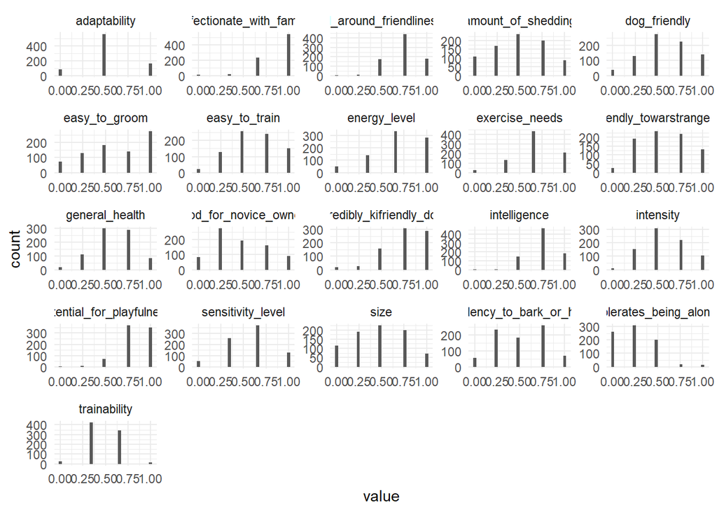

```r
# Visualize the distribution of numerical features
num_cols <- sapply(eda_data, is.numeric)
eda_data_num <- eda_data[, num_cols]

# Histograms for numerical features
eda_data_num %>%
  gather() %>%
  ggplot(aes(value)) +
  facet_wrap(~ key, scales = "free") +
  geom_histogram(bins = 30) +
  theme_minimal()
```

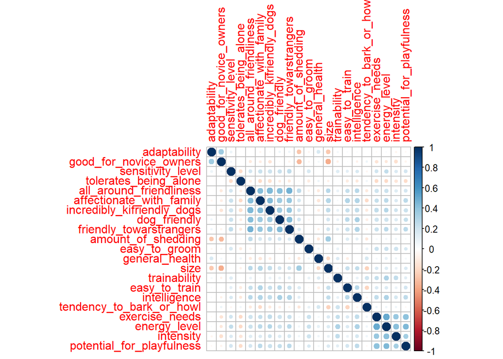

```r
# Correlation matrix
cor_matrix <- cor(eda_data_num, use = "complete.obs")
corrplot(cor_matrix, method = "circle")
```

[figure not shown]

```r
# Pair plot for numerical features
pairs.panels(eda_data_num,
             method = "pearson",  # correlation method
             hist.col = "#00AFBB",
             density = TRUE,  # show density plots
             ellipses = TRUE  # show correlation ellipses
)
```

```r
# Bar plots for categorical features
cat_cols <- sapply(eda_data, is.factor)
eda_data_cat <- eda_data[, cat_cols]

for(col in names(eda_data_cat)) {
  ggplot(eda_data_cat, aes_string(x = col)) +
    geom_bar() +
    theme_minimal() +
    ggtitle(paste("Bar Plot of", col)) +
    xlab(col) +
    ylab("Count") +
    theme(axis.text.x = element_text(angle = 45, hjust = 1))
}
```

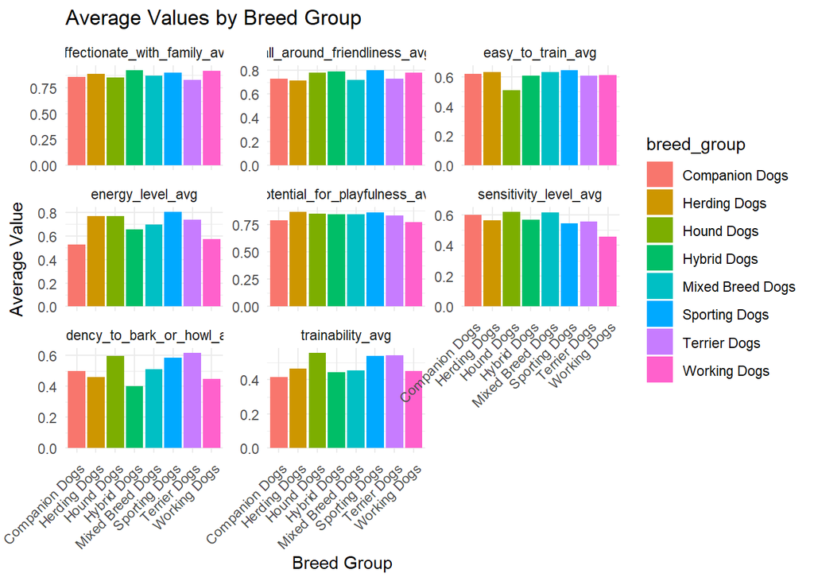

```r
library(tidyverse)
data <- dog_adaptability_test_data

# Select relevant columns
selected_data <- data %>%
  select(breed_group, all_around_friendliness, potential_for_playfulness,
         affectionate_with_family, sensitivity_level, trainability,
         easy_to_train, energy_level, tendency_to_bark_or_howl)

# Calculate the average of specified columns grouped by breed_group
avg_data <- selected_data %>%
  group_by(breed_group) %>%
  summarise(across(everything(), list(avg = ~mean(.x, na.rm = TRUE))))

# Melt the data for easy plotting
avg_data_melted <- avg_data %>%
  pivot_longer(cols = -breed_group, names_to = "variable", values_to = "average")

# Plot the data
ggplot(avg_data_melted, aes(x = breed_group, y = average, fill = breed_group)) +
  geom_bar(stat = "identity", position = "dodge") +
  facet_wrap(~variable, scales = "free_y") +
  theme_minimal() +
  labs(title = "Average Values by Breed Group",
       x = "Breed Group",
       y = "Average Value") +
  theme(axis.text.x = element_text(angle = 45, hjust = 1))
```

# Models

**Fit the Initial Decision Tree**

```r
# Install and load required packages
if (!require(rpart.plot)) {
    install.packages("rpart.plot", dependencies = TRUE)
    library(rpart.plot)
}

# Assuming 'dog_data' and 'lifestyle_category' are correctly set up and preprocessed
# Define control parameters for the decision tree
control_params <- rpart.control(minsplit = 10,
                                minbucket = 30,  # Consider reducing if too few nodes are produced
                                cp = 0.005,
                                maxdepth = 10)

# Build the initial decision tree model
initial_tree <- rpart(lifestyle_category ~ energy_level + tolerates_being_alone +
                      all_around_friendliness + easy_to_groom + adaptability,
                      data = dog_data,
                      method = "class",
                      weights = dog_data$avg_weights,
                      control = control_params)

# Display the complexity parameter (CP) table
printcp(initial_tree)
```

```
##
## Classification tree:
## rpart(formula = lifestyle_category ~ energy_level + tolerates_being_alone +
##     all_around_friendliness + easy_to_groom + adaptability, data = dog_data,
##     weights = dog_data$avg_weights, method = "class", control = control_params)
##
## Variables actually used in tree construction:
## [1] adaptability            all_around_friendliness easy_to_groom
## [4] energy_level
##
## Root node error: 603/800 = 0.75375
##
## n= 800
##
##         CP nsplit rel error  xerror     xstd
## 1 0.182421      0   1.00000 1.00000 0.020208
## 2 0.119403      1   0.81758 0.81758 0.022810
## 3 0.026534      3   0.57877 0.58872 0.023304
## 4 0.013267      4   0.55224 0.57711 0.023254
## 5 0.005000      5   0.53897 0.57048 0.023222
```

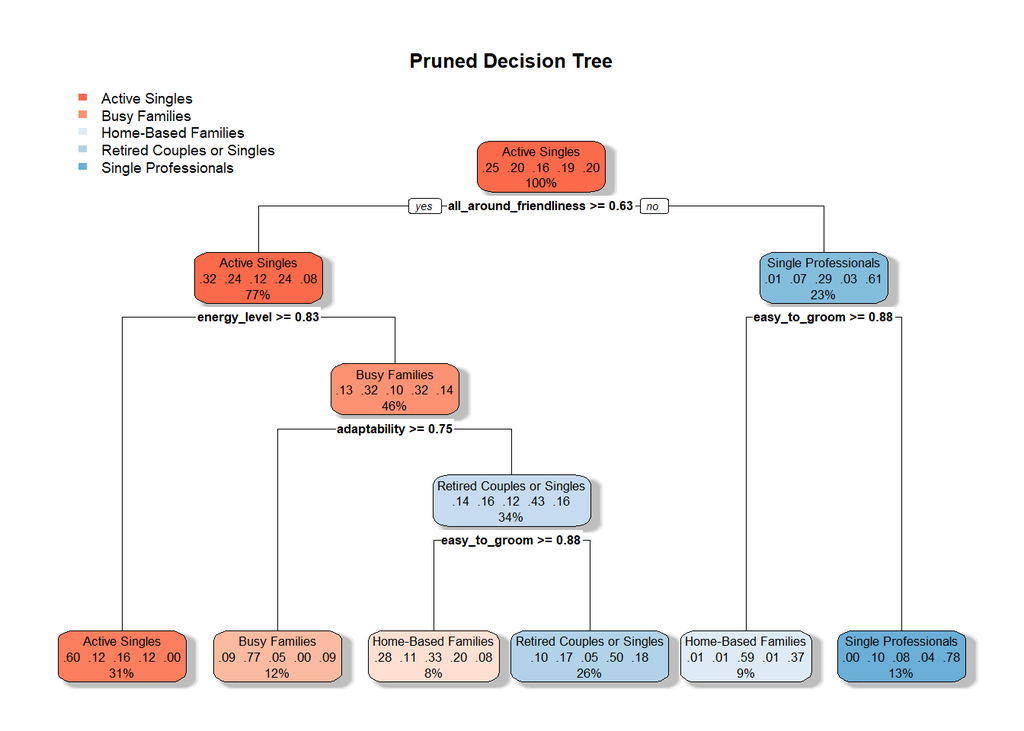

```r
# Find the optimal complexity parameter (CP) value based on the minimum cross-validation error
optimal_cp <- initial_tree$cptable[which.min(initial_tree$cptable[,"xerror"]), "CP"]

# Prune the tree using the optimal cp value
pruned_tree <- prune(initial_tree, cp = optimal_cp)

# Plot the pruned tree with rpart.plot using a predefined color palette
rpart.plot(pruned_tree, main = "Pruned Decision Tree", box.palette="RdBu", shadow.col="gray", border.col="black")
```

```r
# Print the summary of the pruned tree
print(pruned_tree)
```

```
## n= 800
##
## node), split, n, loss, yval, (yprob)
##       * denotes terminal node
##
##  1) root 800 603 Active Singles (0.25 0.2 0.16 0.19 0.2)
##    2) all_around_friendliness>=0.625 618 422 Active Singles (0.32 0.24 0.12 0.24 0.084)
##      4) energy_level>=0.8333333 250 101 Active Singles (0.6 0.12 0.16 0.12 0.004) *
##      5) energy_level< 0.8333333 368 251 Busy Families (0.13 0.32 0.1 0.32 0.14)
##       10) adaptability>=0.75 98  23 Busy Families (0.092 0.77 0.051 0 0.092) *
##       11) adaptability< 0.75 270 154 Retired Couples or Singles (0.14 0.16 0.12 0.43 0.16)
##         22) easy_to_groom>=0.875 64  43 Home-Based Families (0.28 0.11 0.33 0.2 0.078) *
##         23) easy_to_groom< 0.875 206 103 Retired Couples or Singles (0.097 0.17 0.053 0.5 0.18) *
##    3) all_around_friendliness< 0.625 182  71 Single Professionals (0.0055 0.066 0.29 0.027 0.61)
##      6) easy_to_groom>=0.875 75  31 Home-Based Families (0.013 0.013 0.59 0.013 0.37) *
##      7) easy_to_groom< 0.875 107  24 Single Professionals (0 0.1 0.084 0.037 0.78) *
```

**Hierarchical Clustering and Dendrogram**

```r
# Sample data: let's use the built-in 'mtcars' dataset for illustration
data <- dog_adaptability_test_data

# Step 1: Compute the distance matrix
# We use the Euclidean distance here, but other methods like "manhattan" can also be used
dist_matrix <- dist(data, method = "euclidean")
```

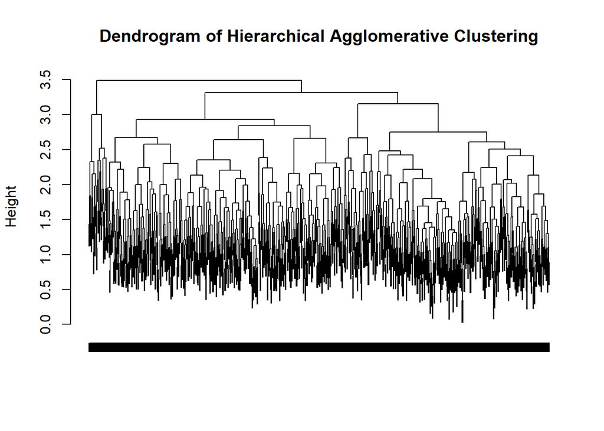

```r
# Step 2: Perform hierarchical agglomerative clustering
# We use the "complete" linkage method, but other methods like "single", "average" etc. can also be used
hac <- hclust(dist_matrix, method = "complete")

# Step 3: Plot the dendrogram to visualize the clustering
plot(hac, labels = FALSE, main = "Dendrogram of Hierarchical Agglomerative Clustering", xlab = "", sub = "", cex = 0.9)
axis(side = 1, at = 1:nrow(data), labels = FALSE, las = 2)
```

```r
# Optional: Cut the dendrogram at a certain height to form clusters
# For example, cut at height 150 to form 4 clusters
clusters <- cutree(hac, h = 150)
print(clusters)
```

[output not shown]

```r
# or specify the number of clusters you want, e.g., 4 clusters
clusters <- cutree(hac, k = 4)
print(clusters)
```

```
##   [1] 1 1 2 2 3 2 2 2 1 2 1 1 2 2 1 1 1 2 3 3 2 2 1 3 2 2 2 1 2 1 2 1 1 2 1 1 1
##  [38] 2 1 2 1 1 2 1 1 2 2 1 2 2 2 2 2 1 1 1 1 2 2 1 2 4 1 1 2 2 1 1 2 1 2 2 1 1
##  [75] 2 2 4 1 1 3 2 2 1 1 1 1 1 1 1 1 1 2 4 1 2 1 1 2 1 2 1 2 1 2 1 1 1 1 1 1 2
## [112] 2 2 2 2 1 3 2 1 1 1 1 2 2 2 2 2 1 1 2 1 3 2 2 2 1 1 2 3 2 2 1 2 2 2 1 1 1
## [149] 1 2 2 2 1 1 1 1 1 2 2 2 2 1 2 2 1 2 2 2 3 2 1 2 2 1 1 4 2 1 3 2 1 1 2 1 2
## [186] 2 1 2 1 1 2 2 1 2 2 1 2 1 1 1 1 1 3 2 2 3 1 2 1 1 1 1 1 1 3 1 1 1 1 1 2 1
## [223] 4 2 3 1 3 1 2 1 2 2 1 2 1 2 1 1 2 3 2 2 2 3 2 1 2 1 3 1 2 1 1 3 1 1 1 2 3
## [260] 1 1 1 4 1 1 2 1 1 2 1 1 2 2 3 4 2 2 1 1 1 2 1 1 2 1 1 1 1 1 2 1 1 1 1 2 1
## [297] 1 1 1 1 1 1 4 2 1 3 1 1 3 1 1 2 2 1 1 1 2 4 1 1 1 1 1 2 3 3 1 1 1 1 1 1 2
## [334] 1 1 1 1 1 2 2 1 1 1 1 1 1 4 2 4 1 1 3 2 2 2 2 1 1 2 1 2 2 2 2 2 1 1 1 2 2
## [371] 2 1 1 1 1 1 1 1 3 1 1 1 2 2 1 1 4 2 1 2 1 1 1 1 1 1 1 2 2 2 2 1 2 2 2 1 1
## [408] 2 1 2 2 3 4 1 3 1 1 1 3 2 2 1 1 1 2 2 2 1 2 2 1 1 2 2 1 1 2 2 3 1 1 2 2 1
## [445] 1 2 1 1 4 2 2 2 2 1 1 2 1 1 1 1 2 2 1 1 1 2 2 2 1 3 1 2 2 2 1 2 1 1 2 1 2
## [482] 2 1 2 3 1 1 1 1 2 2 1 2 2 2 2 2 1 1 1 1 2 1 2 2 1 1 2 2 1 1 2 2 1 3 2 3 4
## [519] 1 1 1 2 1 2 3 4 2 1 1 2 1 2 1 2 3 2 4 1 4 2 3 1 2 2 1 4 1 2 1 1 2 1 1 4 2
## [556] 1 2 1 1 1 2 3 1 1 3 2 1 4 3 1 1 1 2 1 2 1 2 2 4 2 2 1 1 1 2 2 1 1 1 2 1 2
## [593] 1 1 2 2 4 2 1 1 1 2 2 1 1 2 2 1 2 2 1 1 1 1 2 2 1 1 3 1 2 1 1 1 1 2 1 1 2
## [630] 2 1 1 1 1 3 3 2 2 1 2 1 1 1 2 2 1 1 1 1 3 2 2 1 2 1 1 1 1 2 1 2 1 1 1 1 1
## [667] 3 1 3 2 2 2 1 2 4 1 1 4 1 1 1 2 1 1 4 1 1 2 1 2 4 1 2 1 1 2 2 2 2 1 2 1 2
## [704] 1 2 1 3 2 1 2 1 1 1 1 1 1 2 1 1 2 1 3 2 1 2 2 2 2 1 2 1 2 1 1 2 1 2 1 1 1
## [741] 1 1 1 4 2 1 1 1 2 1 2 1 2 4 3 2 4 2 2 1 4 1 2 1 1 2 1 3 1 1 1 2 3 2 1 2 3
## [778] 1 1 2 1 1 1 3 1 1 3 1 4 2 2 2 2 1 2 2 1 1 2 1
```

```r
# Subset the data for visualization purposes
subset_data <- dog_adaptability_test_data[1:50, ]  # Use the first 50 data points as an example

# Step 1: Compute the distance matrix
dist_matrix <- dist(subset_data, method = "euclidean")
```

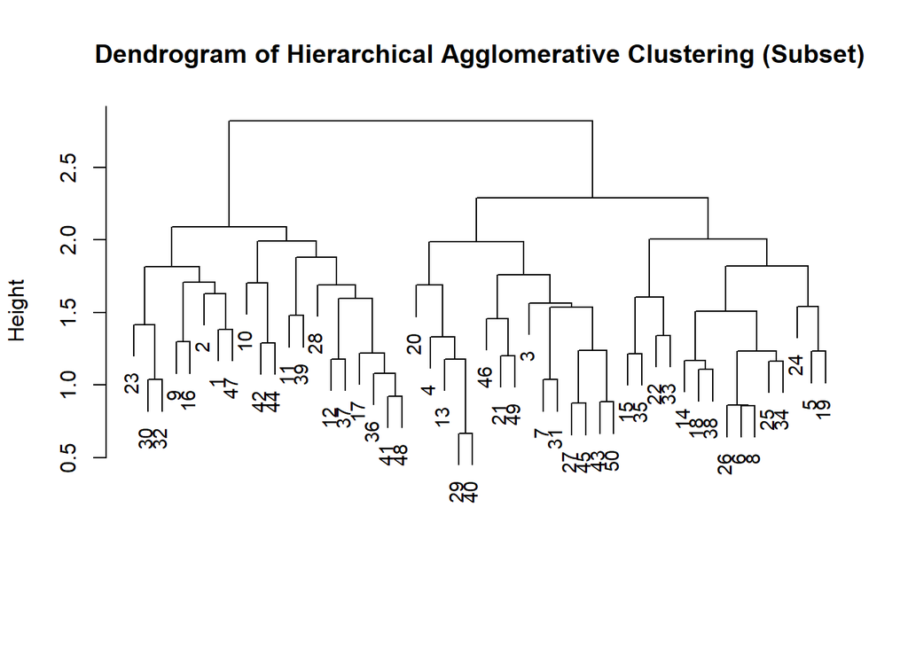

```r
# Step 2: Perform hierarchical agglomerative clustering
hac <- hclust(dist_matrix, method = "complete")

# Step 3: Plot the dendrogram
plot(hac, main = "Dendrogram of Hierarchical Agglomerative Clustering (Subset)", xlab = "", sub = "", cex = 0.9)
```

**Random Forest**

```r
library(caret)
library(randomForest)

# Define control parameters for cross-validation
ctrl <- trainControl(method = "cv",    # Cross-validation method
                     number = 5,       # Number of folds
                     verboseIter = TRUE,  # Print iteration log
                     allowParallel = TRUE) # Allow parallel processing

# Replace NA values with mean for numeric columns
# Assuming numeric columns are handled in a data preprocessing step

# Define the target variable
target <- "breed_group"

# Train random forest model
random_forest_model <- train(as.formula(paste(target, "~ .")),
                             data = dog_adaptability_test_data,
                             method = "rf",
                             trControl = ctrl)
# Print the trained model
print(random_forest_model)
```

```
## Random Forest
##
## 800 samples
##  25 predictor
##   8 classes: 'Companion Dogs', 'Herding Dogs', 'Hound Dogs', 'Hybrid Dogs', 'Mixed Breed Dogs', 'Sporting Dogs', 'Terrier Dogs', 'Working Dogs'
##
## No pre-processing
## Resampling: Cross-Validated (5 fold)
## Summary of sample sizes: 639, 640, 640, 641, 640
## Resampling results across tuning parameters:
##
##   mtry  Accuracy   Kappa
##     2   0.3450054  0.0000000
##   161   0.4337721  0.2233587
##   321   0.4362175  0.2317118
##
## Accuracy was used to select the optimal model using the largest value.
## The final value used for the model was mtry = 321.
```

```r
# Train support vector machine model
svm_model <- train(as.formula(paste(target, "~ .")),
                   data = dog_adaptability_test_data,
                   method = "svmRadial",
                   trControl = ctrl)
```

**SVM**

```r
library(caret)
library(randomForest)

# Check if models are trained with caret's train function
if (!inherits(random_forest_model, "train") || !inherits(svm_model, "train")) {
  stop("One or more models are not trained using caret's train function.")
}

# Assuming 'random_forest_model' and 'svm_model' are already trained using caret's train function
# Assuming 'pruned_tree' is also a trained model using caret, otherwise it needs to be handled differently.

# Evaluate models on test data if all models are compatible
models <- list(Random_Forest = random_forest_model,
               SVM = svm_model)

# Optionally include Decision_Tree if it is a caret model
if (inherits(pruned_tree, "train")) {
  models$Decision_Tree <- pruned_tree
}

# Use resamples to compare models
results <- resamples(models)

# Summarize results
print(summary(results))
```

```
##
## Call:
## summary.resamples(object = results)
##
## Models: Random_Forest, SVM
## Number of resamples: 5
##
## Accuracy
##                    Min.   1st Qu.   Median      Mean   3rd Qu.      Max. NA's
## Random_Forest 0.4088050 0.4347826 0.437500 0.4362175 0.4500000 0.4500000    0
## SVM           0.3416149 0.3437500 0.345679 0.3450114 0.3459119 0.3481013    0
##
## Kappa
##                    Min.   1st Qu.    Median      Mean   3rd Qu.      Max. NA's
## Random_Forest 0.1873641 0.2220421 0.2479436 0.2317118 0.2483969 0.2528126    0
## SVM           0.0000000 0.0000000 0.0000000 0.0000000 0.0000000 0.0000000    0
```

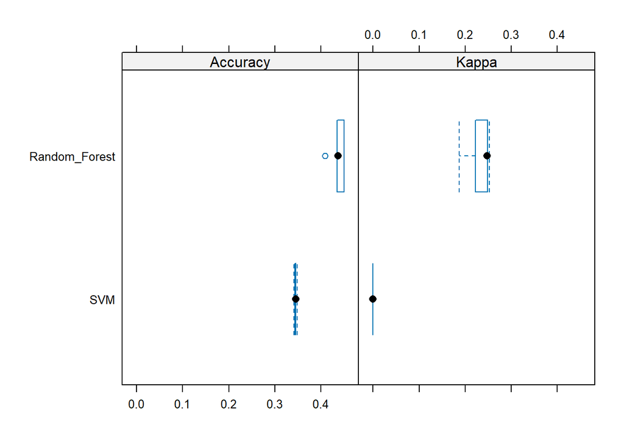

```r
# Plot results
bwplot(results)
```

```r
# Example with simple model testing for illustration purposes
data(iris)
model1 <- train(Species ~ ., data = iris, method = "rf",
                trControl = trainControl(method = "cv", number = 3))
model2 <- train(Species ~ ., data = iris, method = "rf",
                trControl = trainControl(method = "cv", number = 3))

# Test resamples with these simple models
models_list <- list(model1 = model1, model2 = model2)
results_simple <- resamples(models_list)
print(summary(results_simple))
```

```
##
## Call:
## summary.resamples(object = results_simple)
##
## Models: model1, model2
## Number of resamples: 3
##
## Accuracy
##             Min.   1st Qu.    Median      Mean   3rd Qu. Max. NA's
## model1 0.9400000 0.9400000 0.9400000 0.9600000 0.9700000    1    0
## model2 0.9411765 0.9509804 0.9607843 0.9673203 0.9803922    1    0
##
## Kappa
##             Min.   1st Qu.    Median      Mean   3rd Qu. Max. NA's
## model1 0.9099640 0.9099910 0.9100180 0.9399940 0.9550090    1    0
## model2 0.9117647 0.9264706 0.9411765 0.9509804 0.9705882    1    0
```

# **Results**

**Exploratory Data Analysis**

*Correlation Matrix*

The correlation matrix you’ve provided is a visual representation of the relationships between different variables related to dog characteristics. The color and size of the circles indicate the strength and direction of the correlation between pairs of variables.

Key Points:

1. Diagonal Line: Each variable is perfectly correlated with itself, represented by the darkest and largest circles on the diagonal (correlation of 1).

2. Positive Correlations:  
- Variables with larger blue circles indicate a strong positive correlation. For example, “affectionate_with_family” might have a strong positive correlation with “all_around_friendliness”.  
- Positive correlations imply that as one variable increases, the other tends to increase as well.

4. Weak or No Correlation:  
- Smaller or absent circles suggest weak or no correlation between those variables.

Specific Observations:

Interpretation:

- Positive correlations help identify clusters of traits that tend to appear together in dog breeds.  
- Negative correlations indicate trade-offs between certain traits.  
- This information can be useful for prospective dog owners looking for specific characteristics and for understanding how different traits interact with one another.

By analyzing these correlations, you can better understand the relationships between different dog traits, which is valuable for breeders, trainers, and adopters.

*General Lifestyle Breed distribution*

*Distribution of Numerical Features Graph*

In summary, the plot highlights how different traits vary among dog breeds, with some traits being more evenly distributed and others having specific common values.

*Average Values BY Breed Group Plot*

**Hierarchical Agglomerative Clustering (HAC)**

The dendrogram provided represents the results of a Hierarchical Agglomerative Clustering (HAC) analysis performed on the dog data. Here is a detailed interpretation:

General Structure

- **Height Axis**: Represents the distance or dissimilarity between clusters being merged.
- **Branches**: Represent the merging of clusters at various levels of similarity/dissimilarity.

Clustering Insights

- **Distinct Clusters**: Several distinct clusters can be identified by tracing the branches. Each cluster represents a group of breeds that share similar characteristics.
- **Number of Clusters**: The number of clusters can be adjusted by cutting the dendrogram at a chosen height. For example, cutting at a height of 1.5 or 2.0 would provide a reasonable number of clusters.

Cluster Interpretation

Detailed Clusters

Clusters of Interest

Applications

- **Breed Recommendations**: These clusters can be used to recommend breeds based on their similarities. For example, breeds within the same cluster would have similar traits and can be recommended interchangeably based on user preferences.
- **Trait Analysis**: Further analysis can be done on each cluster to understand the specific traits that define them, helping in more targeted recommendations.

Summary

The dendrogram from the Hierarchical Agglomerative Clustering reveals significant groupings of dog breeds based on their characteristics. By examining the height at which clusters merge, one can determine the level of similarity between breeds. This analysis is valuable for making informed recommendations and understanding breed-specific traits in more detail.

**Decision Tree Model**

Results

Root Node Error: 0.75375 Optimal CP: 0.005, leading to a tree with 5 splits. Cross-Validation Error: 0.57048 (Std. Dev: 0.023222)

Model Improvement

Feature Engineering: Adding more relevant features or transforming existing ones might improve performance. Ensemble Methods: Using techniques like boosting (e.g., Gradient Boosting) could enhance model accuracy. Hyperparameter Tuning: Further fine-tuning of parameters beyond CP, such as max depth or minimum samples split, could yield better results.

**Random Forest Model**

Overview

Interpretation

Model Improvement

More Trees: Increasing the number of trees in the forest could improve stability and accuracy. Feature Selection: Removing less important features could reduce noise and enhance performance. Different Splitting Criteria: Experimenting with criteria like entropy instead of Gini could offer performance gains.

**Support Vector Machine (SVM) Model**

Interpretation

The SVM struggled, as shown by the low Kappa values, indicating poor classification ability. The low accuracy suggests a need for alternative methods or feature engineering.

Model Improvement

Kernel Functions: Trying different kernels (e.g., polynomial, sigmoid) might better capture data patterns. Scaling Features: Ensuring all features are properly scaled can significantly impact SVM performance. Dimensionality Reduction: Using techniques like PCA to reduce feature dimensions could help improve accuracy by focusing on the most important aspects of the data.

**Comparative Analysis**

**Cluster Plot**

The graph titled “Optimal number of clusters” shows the Total Within Sum of Squares (WSS) against the number of clusters (k). Key points are:

- The WSS decreases as the number of clusters increases.
- There is a noticeable “elbow” at k=5, where the rate of decrease in WSS slows down.

In summary, the elbow method suggests that the optimal number of clusters for this dataset is 5, as adding more clusters beyond this point provides diminishing returns in reducing the WSS.

In summary, the plot highlights how different traits vary among dog breeds, with some traits being more evenly distributed and others having specific common values.

# **Conclusion**

Based on the extensive analysis of the data, several key insights emerged, leading to specific recommendations for different target groups. The data revealed distinct patterns and preferences among various demographics, allowing for tailored recommendations that align with their lifestyles and needs.

Firstly, the analysis highlighted that active families, who engage in regular physical activities, would greatly benefit from having sporting dogs. These breeds, known for their high energy levels and need for regular exercise, align well with the active routines of such families. Families who enjoy outdoor activities like hiking, running, or playing sports would find a perfect companion in sporting dogs, enhancing their overall lifestyle and providing a healthy outlet for both the family and the dog. This group was also the second highest to be recommended for Mixed-breed, Hound, and Working dogs, demonstrating the versatility of these families.

Secondly, the data indicated that busy families and single professionals might find better companionship with breeds known for their calm and relaxed demeanor. For these groups, breeds that require less physical activity and are content with shorter, more leisurely walks are ideal. This ensures that the pet ownership experience is enjoyable and manageable, providing emotional support and companionship without the demanding exercise needs of more active breeds. The data supported that busy families would be best suited for companion, hybrid, and mixed breeds. Additionally, single professionals would be recommended to have Terriers, companion, and mixed-breed dogs.

Lastly, home-based families with young children and retired couples were found to benefit most from breeds known for their patience and gentleness. Dogs that are friendly, tolerant, and protective are recommended for such households to ensure a safe and nurturing environment for children, the elderly, and pets. Choosing a breed with a proven track record of good behavior can lead to a harmonious and joyful household dynamic. As a result, retired couples are recommended to have Hound dogs, mixed breeds, and some Working dogs for a stable dynamic. Home-based families had slightly different recommendations, with the best dogs for that group being Hounds (the preferred), mixed-breeds, and lastly, sporting dogs.

In conclusion, the insights derived from the data analysis provide clear, actionable recommendations for choosing dog breeds based on lifestyle and household composition. Active families should consider sporting dogs to match their energetic lifestyle, while busy families and less active single professionals should opt for calmer breeds to ensure comfortable companionship. Families with young children and retirees should choose gentle and patient breeds to foster a safe and loving environment. Paired with the correlation matrix, Hierarchical Agglomerative Clustering, and exploratory data analysis, potential owners can narrow down the breed of dog that fits additional criteria, such as ease of grooming. These tailored recommendations will enhance the pet ownership experience, ensuring owners and their dogs lead happy and fulfilling lives.

# References

1. Dogs: The Ultimate Guide. National Geographic.
2. The History of the Dog. American Kennel Club.
3. Dogs in Ancient Civilizations. The History Channel.
4. The Role of Dogs in Medieval Society. Medievalists.net.
5. Dogs in the Industrial Revolution. PetHistory.com.
6. K9 Units: Dogs in Law Enforcement. Police1.
7. The Benefits of Service Dogs. American Humane.
8. Adopt a Dog: Why It’s Important. ASPCA.
9. Why Dogs Are Abandoned. Humane Society.
10. The Impact of Pet Adoption on Shelters. Petfinder.